# Your Digest for Wednesday, Jul 26, 2023 11:59 PM

#2022GM Q12

> The murmur and the gradient across the LVOT will decrease with an increase in preload (Squatting) or an increase in afterload (handgrip). In addition, the gradient and the murmur will increase with a decrease in preload (Valsalva maneuver, diuretics, standing). Certain maneuvers can affect murmurs auscultated in HOCM.

# Associations of lung cancer

#2022GM Q9  
Pancoast tumour  
Hypercalcaemia  
SIADH -> hyponatremia  
Lamber eaton - cereballar ataxia, sensory neuropathy etc.  
Stiff person syndrome - rare  
Hypercoagulable disorders

# Common paraneoplastic syndromes

# Stiff person syndrome

Can be associated with some cancers: thymoma [2,3], Hodgkin's lymphoma [4-6], small cell lung cancer [6,7], and breast cancer.

## Diagnosis:

Clinical  
Then shows demyelinating features on EMG.

[history of methods used to estimate GFR:](https://www.ncbi.nlm.nih.gov/pmc/articles/PMC6188456/)

> Moyamoya disease is **a rare, progressive cerebrovascular disorder caused by blocked arteries at the base of the brain in an area called the basal ganglia**. Moyamoya means “puff of smoke” in Japanese and is used to describe the tangled appearance of tiny vessels compensating for the blockage.

# Sjogren syndrome

#2022GM Q14  
Pathogenesis: Autoimmune disease affecting exocrine glands.

> In most cases, Sjogren syndrome is only 'irritating' and not dangerous.

Can occur as a primary disorder or secondary to another rheumatic disease.

Symptoms are classified mainly as

1. Exocrine gland symptoms
   1. Predominant symptoms of Sjogren's syndrome are
      1. **oral dryness (affects salivary glands)**
      2. **and dry eyes.** - assessed by Schirmer test < 5mm/min.
2. Extra glandular symptoms
   1. Skin :
      1. Xerosis (dryness)
      2. Raynaud's phenomenon
      3. Cutaneous vasculitis: **Palpable purpura** is the commonest manifestation.
   2. Muskuloskelatal: Arthralgria, myopathy, fibromyalgia.
   3. Associated with autoimmune thyroiditis.
   4. Lungs - interstitial lung disease; upper and small airway involvement; Patients have *cough* and dyspnoea.
   5. Peripheral neuropathy
   6. Depression / mood changes/ mild cognitive impairment (maybe due to poor sleep)
   7. Mild anaemia and leukopenia
   8. Other autoimmine diseases
      1. Myasthenia gravis
      2. Autoimmune hepatitis/ pancreatitis.
   9. Increased incidence of Non Hogdkins B lymphoma.
   10. Can cause renal involvement - hypokalemia is common secondary to distal RTA with K+ wasting.
   11. Rare complication of Sjogren syndrome during pregnancy : congenital heart block.

## Spectrum of disease:

*Mild disease* : just dry eyes and mouth; Requires diagnostic criteria to be fullfilled to diagnose SjD.

**Severe disease**:  
A severely affected patient may have florid salivary gland enlargement, adenopathy, antibodies to the Ro/SSA and La/SSB antigens, cryoglobulinemia, hypocomplementemia, a propensity to develop non-Hodgkin lymphoma, and other extraglandular disease manifestations.

90% are positive for Rheumatoid factors: Kumar and Clark

**Epidemiology**: Most Commonly occurs in women aged 50-60 years old.

## Associated conditions

Keratoconjuntivis sicca - term for the occular manifestations of Sojgrens.  
Mikulicz syndrome: Parotid and lacrimal gland enlargement; Sojgren's disease is one possible cause of this.

## Diagnostic criteria:

Biopsy showing focal lymphocytic infitrate of labial salivary glands. Termed **Focal lymphocytic sialadenitis**.  
Objective test: Focal lymphocytic sialadenitis score >= 1;

Anti Ro/SSA and anti La / SSB positivity suggests Sojgren's disease.

Background of systemic autoimmune disease. -  
The most common associations are **SLE** and **Rheumatoid arthritis**.

# Pathogenesis of ascites in Cirrhocis

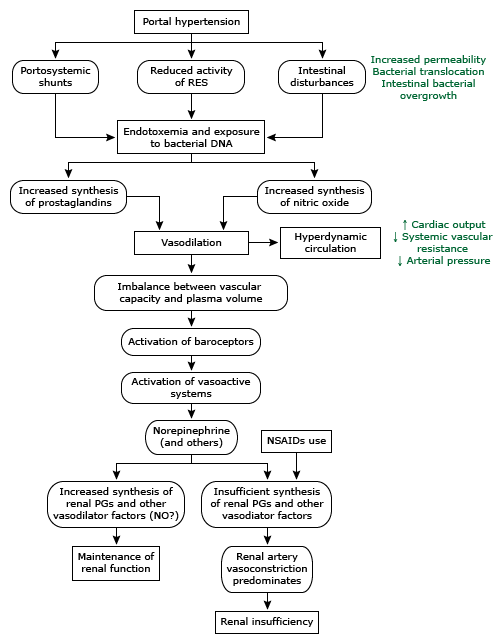

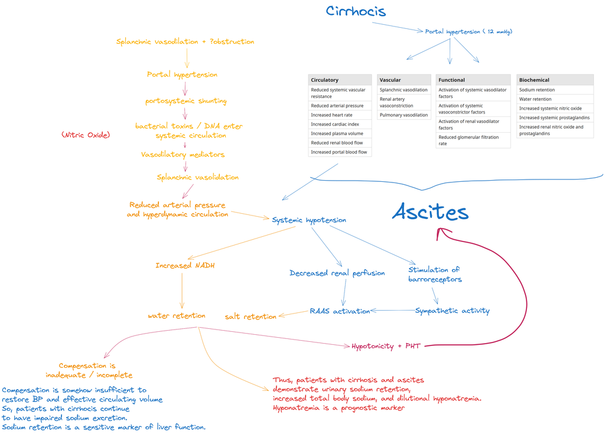

Vascular:

- Decreased peripheral resistance (and reduced arterial pressure)
  - (most apparent in the splanchnic circulation)
- Increased circulatory volume
- Increased cardiac output (and tachycardia)
- Increased portal blood flow
- I.e **Hyperdynamic circulation** is present.  
  but, with
- Decreased renal perfusion (kidneys compensate by increasing their production of prostacyclin - a vasodilator. This effect is lost in patients with **hepatorenal syndrome** and can be inhibited iatrogenically by NSAIDS -> both causing a ==disastrous== fall in renal plasma flow!)

Multiple mediators have been studied as sources of the systemic vasolidation but the most important one seems to be **increased NO synthesis.**

> inhibition of synthesis of NO in rats restores normal arterial pressure.

? cause for increased NO  
Portal hypertension -> increased portosystemic shunting -> decreased hepatic clearance of bacterial toxins / DNA absorbed from GI tract.

mediated by vascular changes:  
Splanchnic vasodilation  
Renal artery vasoconstriction  
(and also pulmonary vasodilation)

Ascites: The pathological accumulation of fluid in the peritoneum.  
Development of portal hypertension is the first step and *is essential* for the formation of ascites in cirrhocis.

Older theories of ascities formation : undefill theory and overflow theory. Modern arterial vasodilation hypothesis fits better with data.

## Arterial vasodilation theory of ascites formation

A portal pressure >12 mmHg appears to be required for fluid retention  
Portal hypertension is not simply due to mechanical obstruction of the portal system. It occurs due to increased flow from the splanchnic arteries.

See hypothesis-highlights on [UpToDate](https://www.uptodate.com/contents/pathogenesis-of-ascites-in-patients-with-cirrhosis?search=Ascites%20CLCD&source=search_result&selectedTitle=6~150&usage_type=default&display_rank=6#H1)

### SAAG

Serum 'to' Ascites Albumin gradient

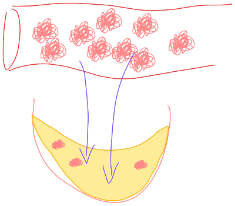

SAAG > 11g/L - low protein in ascitic fluid => Suggest portal hypertension as cause; (i.e transudate)  
SAAG < 11g/L - high protein in ascitic fluid (or low serum protein) => Exudate (?malignancy)

Low ascitic fluid protein may increase the risk of SBP as there are no opsonins in the fluid to combat infection.

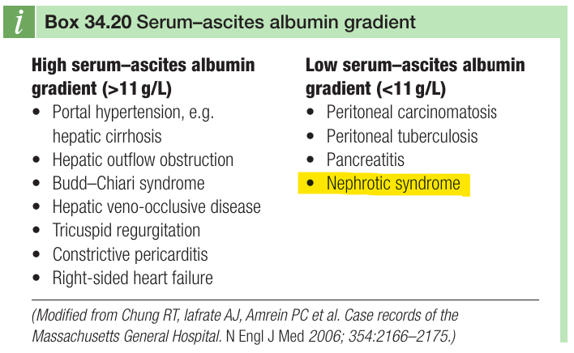

### Liver transplantation

#### Indications for liver transplantation

1. Acute liver failure of any cause
2. Chronic hepatic failure with Childs grade > C or MELD > 20;
   1. hepatopulmonary syndrome can be reversed by hepatic transplantation.
3. Primary biliary cholangitis
4. **Chronic hepatitis B** is HBV DNA negative or falling; recurrence of infection is prevented by HBIG and nucleoside analogues.
5. Autoimmune hepatitis
6. Alcoholic
7. Metabolic disorders - haemochromatosis, Wilsons, Alaph a antitrypsin deficiency
8. NASH cirrhocis

# Bronchiectasis

[figure not shown]